# Level1 - Geomを知る

## scale_x_continuous, scale_y_continuous - グラフの表示範囲を変更する、目盛を変える

特に軸が連続変数の場合、特定の領域に制限してプロットしたいときがあると思います。これには、軸タイトルの設定でも出てきた scale ファミリーの内、scale_x_continuous, scale_y_continuous を使います。

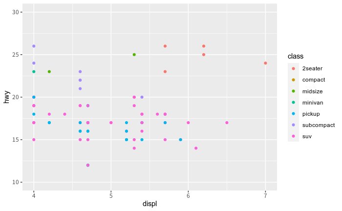

```r
p +
  scale_x_continuous(limits = c(4,7)) +
  scale_y_continuous(limits = c(10, 30))
```

目盛の間隔を変えたいときは、breaks を設定します。breaks には、刻みのベクトル（データ列）を指定する必要があります。例えば、x軸を 1, 1.5, 2 …、y軸を 10, 12.5, 15.0, … としたい場合は、R の関数 seq() を使うと簡単です。

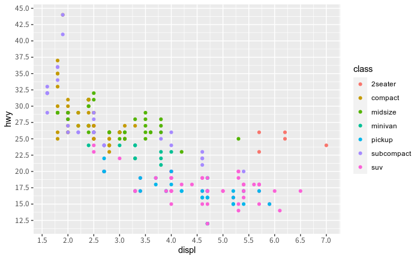

```r
# 目盛りを変える
p +
  scale_x_continuous(breaks = seq(1, 7, by = 0.5)) +
  scale_y_continuous(breaks = seq(10, 50, by = 2.5))
```

seq() は sequential（シーケンシャル）の意味で、等間隔に増えるベクトルを作る関数です。上で使ったデータの中身を見てみると、

```r
seq(1, 7, by = 0.5)
```

```
 [1] 1.0 1.5 2.0 2.5 3.0 3.5 4.0 4.5 5.0 5.5 6.0 6.5 7.0
```

scale_x_continuous の breaks は、このデータにしたがって目盛の刻みを指定するようになっています。

## 目盛線の体裁を変える - theme 再び

印刷すると目盛線が消えてしまう、とかそもそも表示したくない、とかいうときに使います。

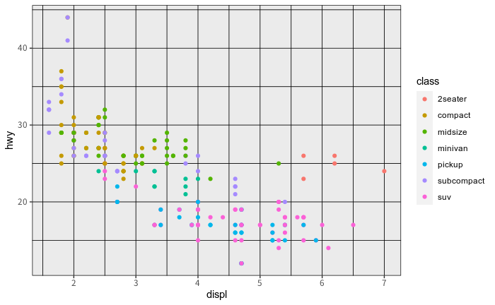

```r
# 目盛線の色や太さを変える
p +
  theme(
    panel.border = element_rect(color = "black", fill = NA),
    panel.grid.major = element_line(color = "black", size = 0.3),
    panel.grid.minor = element_line(color = "black", size = 0.3)
    )
```

非表示にする場合は、次のように指定します。

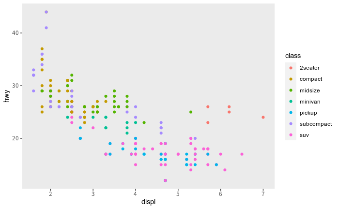

```r
# 目盛線を非表示にする
p +
  theme(
    panel.grid.major = element_blank(),
    panel.grid.minor = element_blank()
    )
```

# cood_flip - 軸を入れ替える

棒グラフや箱ひげ図のときに、ラベルが見えにくいなどの理由で変更したいときがあります。

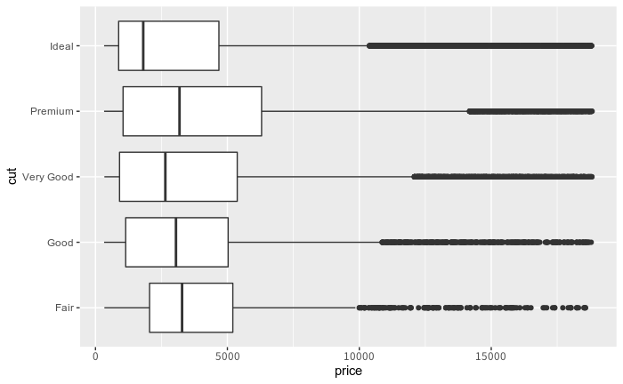

```r
ggplot(diamonds, aes(cut, price)) +
  geom_boxplot() +
  coord_flip()
```

今回は以上で終了です。次回は、データセットの作り方について、基礎の基礎から紹介します。